# Transit Oriented Development in Essex-Hudson Counties

By Stephanie Onuaja

September 9, 2022

**Analyzing Transit Oriented Development Potential in Essex-Hudson, NJ**

Taking the combined geographies of Essex and Hudson Counties, this analysis aims to assess the potential for transit-oriented development around the Hudson–Bergen Light Rail and Newark City Subway lines. It hopes to evaluate the indicators suggestive of that potential identified between 2009 to 2019. Furthermore, it intends to contrast discoveries in non-TOD areas to grasp the perceived value of TOD; and to potentially understand gaps in transport connectivity in the municipalities within these northern New Jersey counties.

**Data Sources**

The demographic and transit data used for this analysis were from the following sources:

- American Community Survey 5-Year Estimates (2009 & 2019)
- New Jersey Geographic Information Network

## 0.1 Setting Up

```r
knitr::opts_chunk$set(
  echo=TRUE,
  include=TRUE,
  warning=FALSE,
  messages=FALSE,
  fig.width = 8,
  fig.keep = 'all',
  collapse=TRUE)

options(scipen=10000000)
options(tigris_class = "sf")

# Load Libraries
library(tidyverse)
library(tidycensus)
library(sf)
library(kableExtra)
library(ggplot2)
library(dplyr)
library(tidyr)
library(RColorBrewer)




# Load Functions
source("https://raw.githubusercontent.com/urbanSpatial/Public-Policy-Analytics-Landing/master/functions.r")

palette5 <- c("#f0f9e8","#bae4bc","#7bccc4","#43a2ca","#0868ac")
palette6 <- c("#f1eef6","#bdc9e1", "#74a9cf", "#2b8cbe", "#045a8d")
palette7 <- c("#c7e9b4", "#7fcdbb", "#41b6c4","#1d91c0", "#225ea8")
```

#### 0.1.0.1 Wrangling ACS Data

```r
# 2009 ACS Data
acs_variable_list.2009 <- load_variables(2009, #year
                                         "acs5", #five year ACS estimates
                                         cache = TRUE)
#Hudson County
tracts09_1 <-
   get_acs(geography = "tract",
          variables = c("B25026_001E","B02001_002E",
                        "B15001_050E","B15001_009E",
                        "B19013_001E", "B25058_001E",
                        "B06012_002E", "B02001_003E"),
          year=2009, state=34, county = 017, geometry=TRUE)

# Essex County
tracts09_2 <-
   get_acs(geography = "tract",
          variables = c("B25026_001E","B02001_002E",
                        "B15001_050E","B15001_009E",
                        "B19013_001E", "B25058_001E",
                        "B06012_002E", "B02001_003E"),
          year=2009, state=34, county = 013, geometry=TRUE)

#Bind geographies
tracts09 <- rbind(tracts09_1,tracts09_2)

# Rename variables and create new variables
tracts09 <-
  tracts09 %>%
  dplyr::select( -NAME, -moe) %>%
  spread(variable, estimate) %>%
  rename(TotalPop = B25026_001,
         Whites = B02001_002,
         Blacks = B02001_003,
         FemaleBachelors = B15001_050,
         MaleBachelors = B15001_009,
         MedHHInc = B19013_001,
         MedRent = B25058_001,
         TotalPoverty = B06012_002)

# New variables using mutate

tracts09 <-
  tracts09 %>%
  mutate(pctWhite = ifelse(TotalPop > 0, Whites / TotalPop, 0),
         pctBlack = ifelse(TotalPop > 0, Blacks / TotalPop, 0),
         pctBachelors = ifelse(TotalPop > 0, ((FemaleBachelors + MaleBachelors) / TotalPop), 0),
         pctPoverty = ifelse(TotalPop > 0, TotalPoverty / TotalPop, 0),
         year = "2009") %>%
  dplyr::select(-Whites,-Blacks,-FemaleBachelors,-MaleBachelors,-TotalPoverty)
```

```r
# 2019 ACS Data
# Hudson County
tracts19_1 <-
   get_acs(geography = "tract",
          variables = c("B25026_001E","B02001_002E",
                        "B15001_050E","B15001_009E",
                        "B19013_001E", "B25058_001E",
                        "B06012_002E", "B02001_003E"),
          year=2019, state=34, county = 017, geometry=TRUE)
# Essex County
tracts19_2 <-
   get_acs(geography = "tract",
          variables = c("B25026_001E","B02001_002E",
                        "B15001_050E","B15001_009E",
                        "B19013_001E", "B25058_001E",
                        "B06012_002E", "B02001_003E"),
          year=2019, state=34, county = 013, geometry=TRUE)

#Bind geographies
tracts19 <- rbind(tracts19_1,tracts19_2)

# Rename variables and create new variables
tracts19 <-
  tracts19 %>%
  dplyr::select( -NAME, -moe) %>%
  spread(variable, estimate) %>%
  rename(TotalPop = B25026_001,
         Whites = B02001_002,
         Blacks = B02001_003,
         FemaleBachelors = B15001_050,
         MaleBachelors = B15001_009,
         MedHHInc = B19013_001,
         MedRent = B25058_001,
         TotalPoverty = B06012_002)

# New variables using mutate
tracts19 <-
  tracts19 %>%
  mutate(pctWhite = ifelse(TotalPop > 0, Whites / TotalPop, 0),
         pctBlack = ifelse(TotalPop > 0, Blacks / TotalPop, 0),
         pctBachelors = ifelse(TotalPop > 0, ((FemaleBachelors + MaleBachelors) / TotalPop), 0),
         pctPoverty = ifelse(TotalPop > 0, TotalPoverty / TotalPop, 0),
         year = "2019") %>%
  dplyr::select(-Whites,-Blacks,-FemaleBachelors,-MaleBachelors,-TotalPoverty)
```

```r
# Bind 2009 data to 2020
allTracts <- rbind(tracts09,tracts19)
```

#### 0.1.0.2 Wrangling Transit Open Data

```r
NJStops <- st_read("Light_Rail_Stations_of_NJ_Transit.geojson")%>%
st_transform(st_crs(tracts09)) %>%
  dplyr:: filter (COUNTY %in% c("Hudson","Essex"))
```

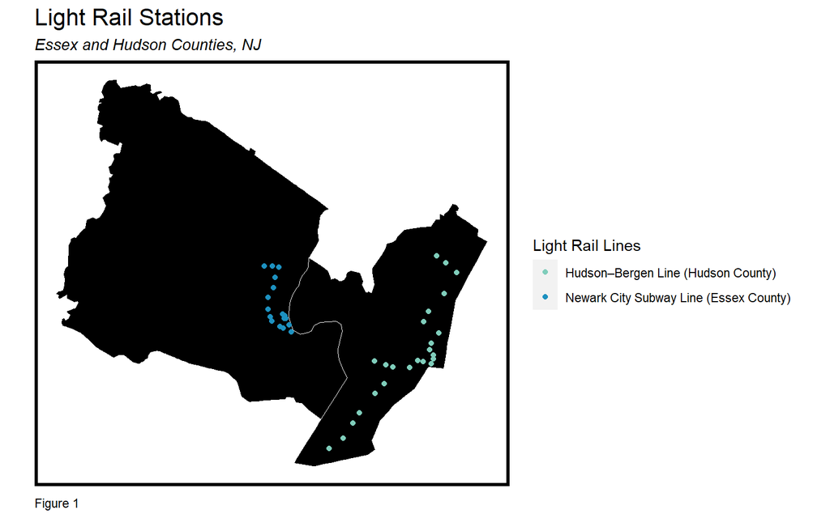

```r
ggplot() +
  geom_sf(data=st_union(tracts09), color = "black", fill = "black")+
  geom_sf(data=st_union(tracts09_1), color = "white", fill = "black")+
  geom_sf(data=NJStops, aes(color = LINE_CODE)) +
  labs(title="Light Rail Stations",
       subtitle="Essex and Hudson Counties, NJ",
       caption="Figure 1")+
   scale_color_manual(labels = c("Hudson–Bergen Line (Hudson County)", "Newark City Subway Line (Essex County)"), values = c("#7fcdbb","#1d91c0"))+
  guides(color=guide_legend("Light Rail Lines"))+
  mapTheme()
```

#### 0.1.0.3 Buffers Around Light Rail Stations

```r
LRBuffers <-
  rbind(
    st_buffer(NJStops, 2640) %>%
      mutate(Legend = "Buffer") %>%
      dplyr::select(Legend),
    st_union(st_buffer(NJStops, 2640)) %>%
      st_sf() %>%
      mutate(Legend = "Unioned Buffer"))
```

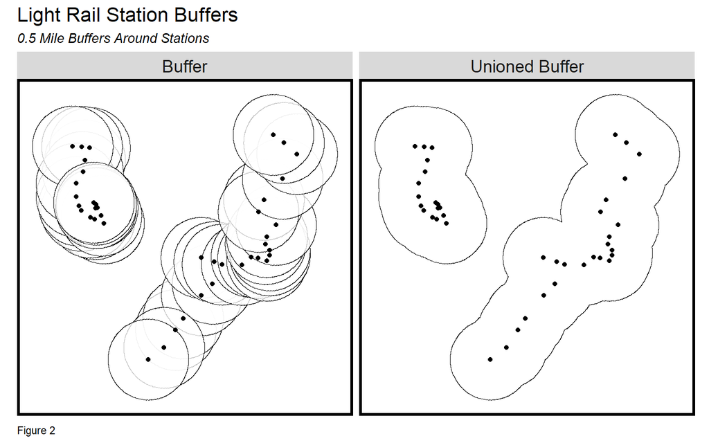

```r
ggplot() +
  geom_sf(data=LRBuffers, fill = "white", color = "black", alpha = 0.75) +
  geom_sf(data=NJStops) +
  facet_wrap(~Legend) +
  labs(title="Light Rail Station Buffers",
       subtitle="0.5 Mile Buffers Around Stations",caption = "Figure 2") +
  theme(legend.position="none")+
  mapTheme()
```

## 0.2 Spatial Operations

```r
buffer <- filter(LRBuffers, Legend=="Unioned Buffer")
sf::sf_use_s2(FALSE)
```

```r
# Spatial clipping at unioned buffer boundaries
clip <-
  st_intersection(buffer, tracts09) %>%
  dplyr::select(TotalPop) %>%
  mutate(Selection_Type = "Clip")

# Spatial selection on polygons touching the buffer
selection <-
  tracts09[buffer,] %>%
  dplyr::select(TotalPop) %>%
  mutate(Selection_Type = "Spatial Selection")

# Spatial intersection with on polygon centroids
selectCentroids <-
  st_centroid(tracts09)[buffer,] %>%
  st_drop_geometry() %>%
  left_join(., dplyr::select(tracts09, GEOID), by = "GEOID") %>%
  st_sf() %>%
  dplyr::select(TotalPop) %>%
  mutate(Selection_Type = "Select by Centroids")
```

#### 0.2.0.1 Plotting Spatial Operations

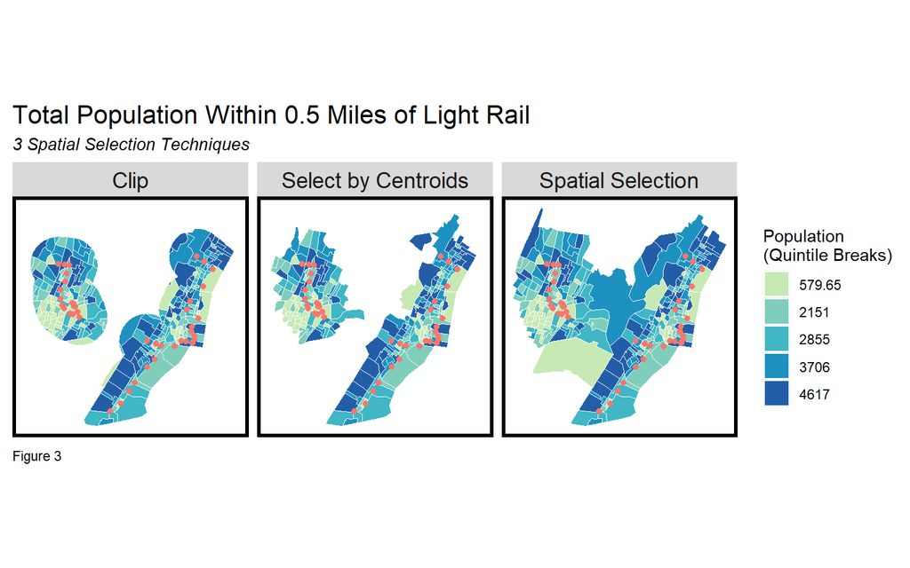

```r
intersections <- rbind(clip, selection, selectCentroids)

ggplot() +
  geom_sf(data=intersections, color = "white", aes(fill = q5(TotalPop))) +
  geom_sf(data=NJStops, aes(color = LAYER)) +
  scale_fill_manual(values = palette7,labels = qBr(intersections, "TotalPop"),
                    name = "Population\n(Quintile Breaks)") +
  facet_wrap(~Selection_Type) +
   labs(title="Total Population Within 0.5 Miles of Light Rail",
       subtitle="3 Spatial Selection Techniques", caption = "Figure 3") +
  guides(color = FALSE)+
  mapTheme()
```

## 0.3 TOD Indicator Maps

```r
allTracts.group <-
  rbind(
    st_centroid(allTracts)[buffer,] %>%
      st_drop_geometry() %>%
      left_join(allTracts) %>%
      st_sf() %>%
      mutate(TOD = "TOD"),
    st_centroid(allTracts)[buffer, op = st_disjoint] %>%
      st_drop_geometry() %>%
      left_join(allTracts) %>%
      st_sf() %>%
      mutate(TOD = "Non-TOD")) %>%
      mutate(MedRent.inf = ifelse(year == "2009", MedRent * 1.19, MedRent)) %>%
      mutate(MedHHInc.inf = ifelse(year == "2009", MedHHInc * 1.19, MedHHInc)) %>%
      mutate(pctPoverty.100 = ifelse(year == "2009", pctPoverty* 100, pctPoverty)) %>%
      mutate(pctBlack.100 = ifelse(year == "2009", pctBlack* 100, pctBlack)) %>%
      mutate(pctWhite.100 = ifelse(year == "2009", pctWhite* 100, pctWhite))
```

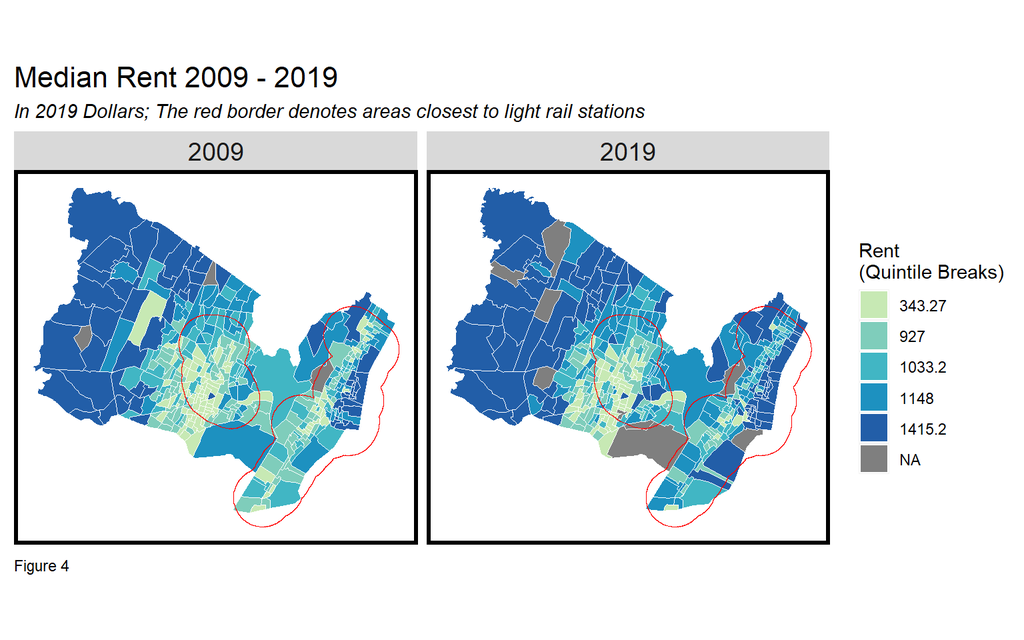

```r
ggplot() +
    geom_sf(data =allTracts.group,aes(fill = q5(MedRent.inf)), color = "white") +
    geom_sf(data = st_union(buffer), fill = "NA", color = "red") +
    scale_fill_manual(values = palette7,
                      labels = qBr(allTracts.group, "MedRent.inf"),
                      name = "Rent\n(Quintile Breaks)") +
    labs(title = "Median Rent 2009 - 2019",
         subtitle = "In 2019 Dollars; The red border denotes areas closest to light rail stations",
         caption = "Figure 4") +
    facet_wrap(~year) +
    mapTheme()
```

Median Rent appears to have increased in areas around transit.

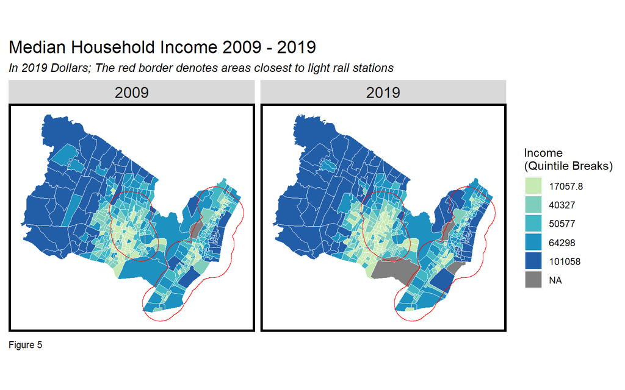

```r
ggplot(allTracts.group) +
    geom_sf(aes(fill = q5(MedHHInc.inf)), color = "white") +
    geom_sf(data = st_union(buffer), fill = "NA", color = "red") +
    scale_fill_manual(values = palette7,
                      labels = qBr(allTracts.group, "MedHHInc.inf"),
                      name = "Income\n(Quintile Breaks)") +
    labs(title = "Median Household Income 2009 - 2019",
         subtitle = "In 2019 Dollars; The red border denotes areas closest to light rail stations",
         caption = "Figure 5") +
    facet_wrap(~year) +
    mapTheme()
```

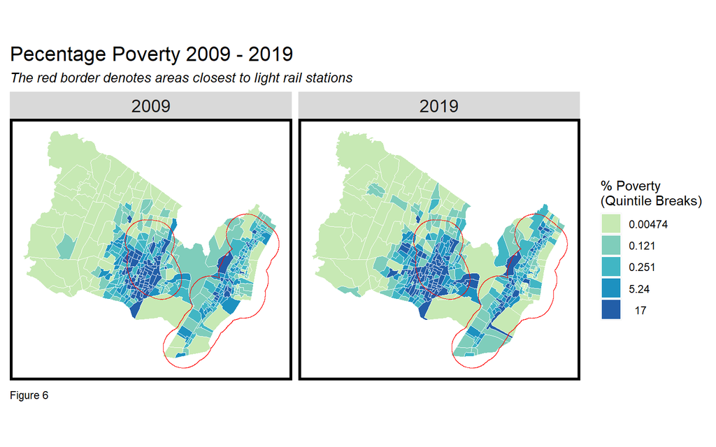

```r
ggplot(allTracts.group) +
    geom_sf(aes(fill = q5(pctPoverty*100)), color = "white") +
    geom_sf(data = st_union(buffer), fill = "NA", color = "red") +
    scale_fill_manual(values = palette7,
                      labels = qBr(allTracts.group,"pctPoverty.100", rnd=F),
                      name = "% Poverty\n(Quintile Breaks)") +
    labs(title = "Pecentage Poverty 2009 - 2019",
         subtitle = "The red border denotes areas closest to light rail stations",
         caption = "Figure 6") +
    facet_wrap(~year) +
    mapTheme()
```

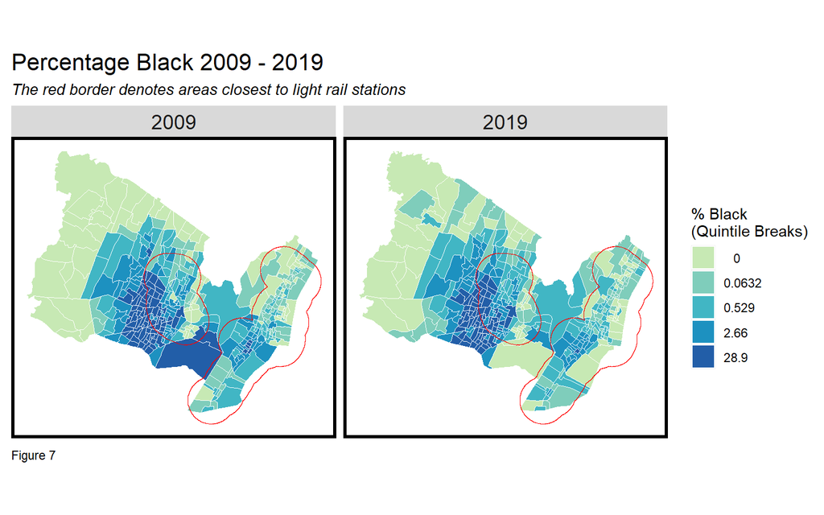

```r
ggplot(allTracts.group) +
    geom_sf(aes(fill = q5(pctBlack*100)), color = "white") +
    geom_sf(data = st_union(buffer), fill = "NA", color = "red") +
    scale_fill_manual(values = palette7,
                      labels = qBr(allTracts.group, "pctBlack.100", rnd=F),
                      name = "% Black\n(Quintile Breaks)") +
    labs(title = "Percentage Black 2009 - 2019",
         subtitle = "The red border denotes areas closest to light rail stations",
         caption = "Figure 7") +
    facet_wrap(~year) +
    mapTheme()
```

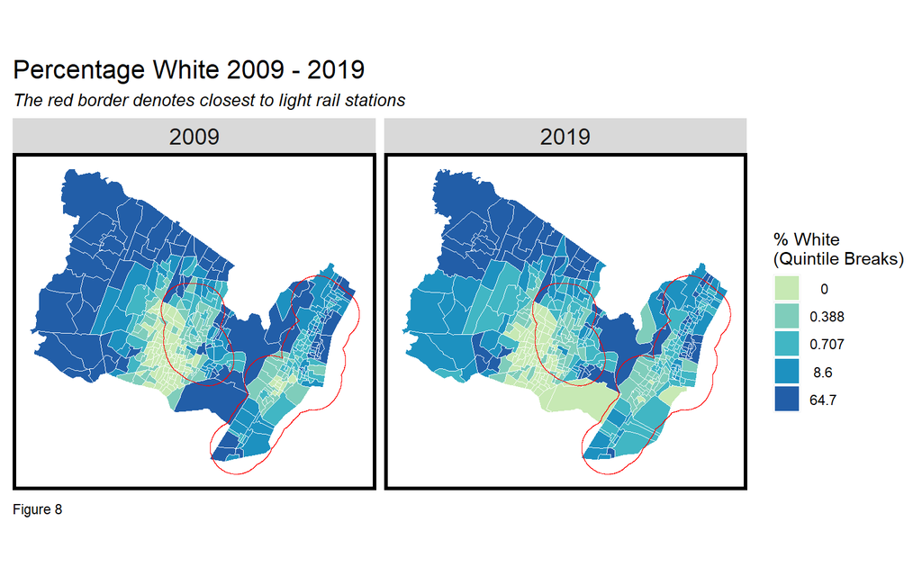

```r
ggplot(allTracts.group) +
    geom_sf(aes(fill = q5(pctWhite*100)), color = "white") +
    geom_sf(data = st_union(buffer), fill = "NA", color = "red") +
    scale_fill_manual(values = palette7,
                      labels = qBr(allTracts.group, "pctWhite.100", rnd=F),
                      name = "% White\n(Quintile Breaks)") +
    labs(title = "Percentage White 2009 - 2019",
         subtitle = "The red border denotes closest to light rail stations",
         caption = "Figure 8") +
    facet_wrap(~year) +
    mapTheme()
```

The map implies a decrease in the White population in non-TOD areas.

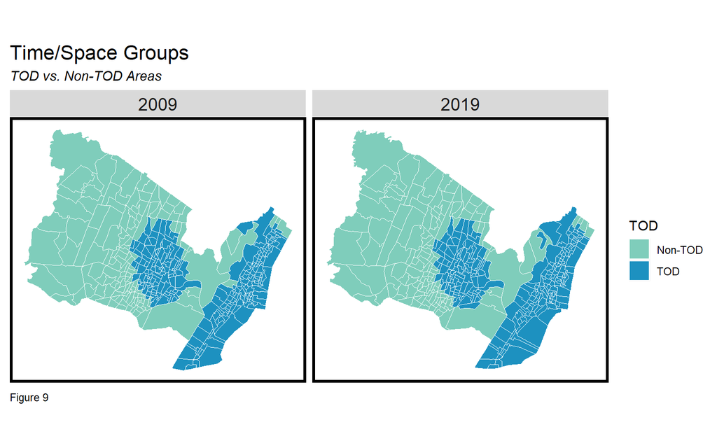

```r
ggplot()+
    geom_sf(data=(tracts09), color = "white") +
    geom_sf(data=allTracts.group, color = "white", aes(fill = TOD)) +
    labs(title = "Time/Space Groups", subtitle="TOD vs. Non-TOD Areas",
         caption = "Figure 9") +
   scale_fill_manual(values = c("#7fcdbb","#1d91c0"))+
    facet_wrap(~year)+
    mapTheme()
```